# PS 12 Notes

Stat 341 — Spring 2017

April 12, 2017

### Think Jointly

In the problem about leg length and height, it is important to think about the **joint** posterior distribution for `bl` and `br`. If you look at the joint distribution, you can see what happens when we truncate the prior for `br`.

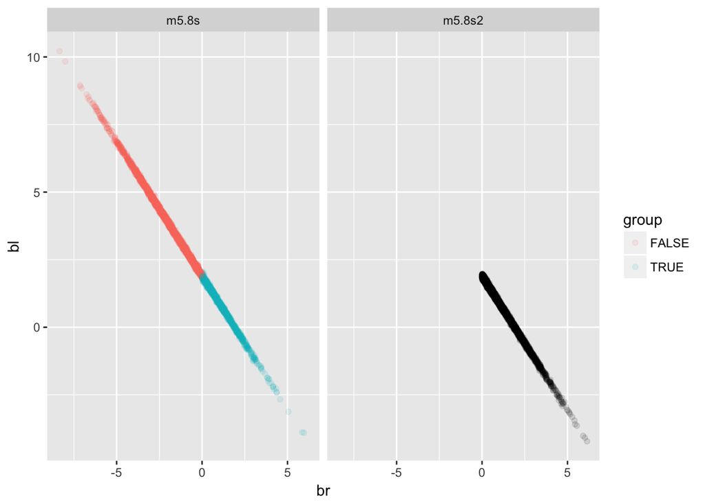

```r
m5.8s_post <- extract.samples(m5.8s) %>%  data.frame() %>%
  mutate(group = br > 0, model = "m5.8s")
m5.8s2_post <- extract.samples(m5.8s2) %>% data.frame() %>%
  mutate(model = "m5.8s2")
gf_point(bl ~ br + color:group, data = m5.8s_post, alpha = 0.1) %>%
  gf_point(bl ~ br, data = m5.8s2_post, alpha = 0.1) %>%
  gf_facet_grid(. ~ model)
```

### Effective number of parameters

Some of you are misunderstanding the notion of “effective number of parameters”. Here are some things it **DOES NOT MEAN**

- It does not try to identify which parameters are “effective” and which are not. It is not “number of effective parameters” (there isn’t such a thing). The fact that you get fractional amounts should be some indication of this.
- It is not trying to measure how “effective” (whatever that means) the parameters are.
- It is not an analogue to “statistical significance” which you might be familiar with from other classes.

**Effective number of parameters is a measure of how flexible the model can be to fit the data.** Generally, as you add parameters to a model, it become more flexible. But models with the same number of parameters are not equally flexible. (This is one of the problems with AIC – it treats all models with the same number of parameters in the same way.) If the effective number of parameters is less than the actual number of parameters, this is an indication that the model is not as flexible as some other models that have the same number of actual parameters. Possible reasons for the difference include:

- priors that restrict the flexibility of the model
- correlation among predictor variables that lead to correlation in the posterior distribution for the parameters (see the leg length and height problem, for example)

For Multi-level models, the effective number of parameters may be much smaller than the actual number of parameters.

Both DIC and WAIC have a notion of “effective number of parameters”. As the effective number of parameters increases, the risk of overfitting increases, so DIC and WAIC decrease there estimate for how well the model will fit out-of-sample accordingly. When comparing based on WAIC or DIC, models with a larger effective number of parameters are required to fit the sample data better than models with a smaller effective number of parameters in order to “win the competition”.

### Divergent Transistions (and other Stan Warnings)

You can find out about what “divergent transitions” means and what things you can do to fix this problem at [http://mc-stan.org/misc/warnings.html](http://mc-stan.org/misc/warnings.html#divergent-transitions-after-warmup).

Other warnings are discussed on the same web page.